# COVID-19 - Previsão usando (auto) ARIMA

Para descobrir o possível padrão de evolução do número de casos confirmados em um cenário em que não houvesse mudança de política é necessário utilizar um modelo estatístico ou de *machine learning* para “prever” o que teria acontecido nos dias seguintes a mudança de política levando-se em conta apenas os dados anteriores. Neste sentido, o modelo estatístico de séries temporais ARIMA (*AutoRegressive Integrated Moving Avarage*, ou modelo auto-regressivo integrado de médias móveis) é apropriada. A intuição geral é usar valores anteriores para explicar os valores atuais em uma série temporal (dados de uma variável distribuídas no tempo).

# ARIMA

## 1. Preparando os dados

A implementação prática do modelo exige que os dados sejam convertidos em uma única coluna com a evolução doa varriável de interesse, no caso, os casos confirmados.

```r
## Limpando R
rm(list=ls())

## Importando dados de Sorocaba
df = openxlsx::read.xlsx("C:/Users/oOluc/Downloads/Telegram Desktop/evolução-corona-sorocaba.xlsx")

## Retirando informações complementares de uma segunda tabela na aba 1
ultima_linha = which(is.na(df$CASOS.CONFIRMADOS))[1]-1
df <- df[1:ultima_linha,]


## Arrumadno data
df$data <- as.Date(df$X2, origin = "1899-12-30")
# Visualizando 5 primeiras datas
df$data[1:5] #ok
```

```
[1] "2020-03-24" "2020-03-25" "2020-03-26" "2020-03-27" "2020-03-28"
```

```r
## Variável contando o dia
df$dia <- df$data[1]
df$dia <- as.numeric(df$data - df$dia)
df$dia <- df$dia + 1
# Visualizando 5 primeiros dias
df$dia[1:5]
```

```
[1] 1 2 3 4 5
```

```r
## Qual dia houve mudança de política (1 de junho)?
reabertura = df$dia[df$data == as.Date("2020-06-1")]

## Subset: apenas a contagem de dias e casos confirmados
df <- df[,c(33,3)]

# Renomeando variáveis
colnames(df) <- c("dia","confirmados")

## Visualizando 5 primeiros
df[1:5,]
```

|  | dia | confirmados |
| --- | --- | --- |
| 1 | 1 | 1 |
| 2 | 2 | 1 |
| 3 | 3 | 2 |
| 4 | 4 | 3 |
| 5 | 5 | 3 |

```r
## Convertendo para tipo numérico
df$confirmados <- as.numeric(df$confirmados)

## Data frame não considerando os últimos dias em que teve mudança de política (1 de Junho)
df0 <- df[1:which(df$dia == (reabertura-1)),]
```

## 2. Escolhendo melhor modelo

Há um comando específico no R capaz de escolher os melhores parâmetros para os modelos ARIMA. São três parâmetros necessário:

1. **p**: quantos valores defasados explicam o valor atual (casos passados nos *p* dias atrás explicam o número do dial de hoje, por exemplo);
2. **d**: quantas vezes deve se subtrair os valores passados para que a série temporal seja estacionária (ou seja, subtrair *d* vezes os valores passados para a série seja uma ‘reta’, em que as variações sejam aleatórias).
3. **q**: capta a evolução da média da série.

```r
## Carrengo biblioteca com comando
library(forecast)
## aplicando
modelo = auto.arima(df0$confirmados)
modelo
```

```
Series: df0$confirmados
ARIMA(0,2,1)

Coefficients:
          ma1
      -0.8253
s.e.   0.0543

sigma^2 estimated as 311.7:  log likelihood=-287.5
AIC=579   AICc=579.18   BIC=583.41
```

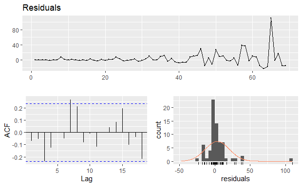

```r
## Checando resíduos do modelo escolhido
checkresiduals(modelo$residuals) #variância crescente (não sei se é ruído branco)
```

Os valores adequados encontrados para o parâmetro foram:

1. $p = 0$;
2. $d = 2$;
3. e $q = 1$.

Com o melhor modelo em mãos, podemos fazer a previsão para os dias de reabertura, com um intervalo de confiança de 95%:

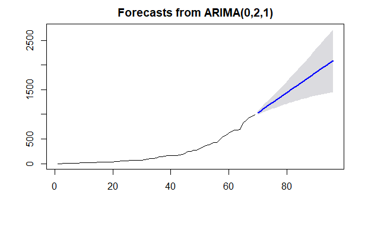

```r
# Previsão
# Quantos dias é necessário fazer a previsão? reabertura até último dia com dados
n_dias_prev = nrow(df) - nrow(df0)

previsao <- forecast(modelo, level=c(95), h=n_dias_prev)

plot(previsao)
```

## 3. Gráfico

Agora que temos os valores previstos para os dias em que houve reabertura caso essa política não fosse em prática é necessário fazer uma representação gráfica comparando o que poderia ter acontecido com o que de fato aconteceu. Para tanto, ao gráfico rudimentar da segunda seção deverá ser adicionado um segmento de linha com os números de casos confirmados a partir de 1 de Junho.

```r
## Carregando o pacote de gráficos
library(ggplot2)

## Adequando os dados
# Adequando objeto com previsao
prev = summary(previsao)
```

```
Forecast method: ARIMA(0,2,1)

Model Information:
Series: df0$confirmados
ARIMA(0,2,1)

Coefficients:
          ma1
      -0.8253
s.e.   0.0543

sigma^2 estimated as 311.7:  log likelihood=-287.5
AIC=579   AICc=579.18   BIC=583.41

Error measures:
                   ME     RMSE      MAE      MPE     MAPE      MASE
Training set 3.324761 17.26784 8.586165 2.326425 6.225621 0.5909506
                    ACF1
Training set -0.07126744

Forecasts:
```

|  | Point Forecast | Lo 95 | Hi 95 |
| --- | --- | --- | --- |
| 70 | 1029.683 | 995.0783 | 1064.288 |
| 71 | 1070.367 | 1016.9822 | 1123.751 |
| 72 | 1111.050 | 1040.1257 | 1181.974 |
| 73 | 1151.733 | 1063.3498 | 1240.117 |
| 74 | 1192.416 | 1086.2698 | 1298.563 |
| 75 | 1233.100 | 1108.7221 | 1357.477 |
| 76 | 1273.783 | 1130.6302 | 1416.936 |
| 77 | 1314.466 | 1151.9579 | 1476.975 |
| 78 | 1355.150 | 1172.6896 | 1537.610 |
| 79 | 1395.833 | 1192.8210 | 1598.845 |

[output cut: 17 more lines]

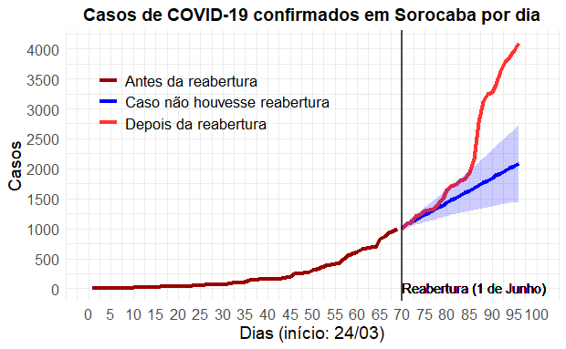

```r
df_prev = data.frame(dia = c(reabertura:nrow(df)),
                     confirmados = prev$`Point Forecast`,
                     ci_lower = prev$`Lo 95`,
                     ci_upper = prev$`Hi 95`
                     )

# Criando variáveis com intervalos de confiança
df$ci_lower = NA
df$ci_upper = NA

# Variável informando se é:
#(i) antes da reabertura;
df$Tipo = NA
df$Tipo[1:(reabertura-1)] = "Antes da reabertura"
#(ii) depois da abertura;
df$Tipo[(reabertura):nrow(df)] = "Depois da reabertura"
#e (iii) caso não houvesse reabertura.
df_prev$Tipo = "Caso não houvesse reabertura"

# Unindo em um único data frame
df = rbind(df,df_prev)


## Gráfico
 p <- ggplot(df, aes(x=dia, y=confirmados, group=reorder(Tipo,confirmados))) +
  geom_line(aes(linetype=reorder(Tipo,confirmados), color=reorder(Tipo,confirmados)),size = 1.5)  + scale_x_continuous(limits = c(0,100),breaks=c(seq(0,100,by=5))) + scale_y_continuous(limits = c(0,4100),breaks=c(seq(0,4000,by=500)))

p <- p + ylab("Casos") +xlab("Dias (início: 24/03)")

p <- p + geom_vline(xintercept = reabertura, size = 1, alpha = 0.7) + geom_text(aes(x=reabertura, label="Reabertura (1 de Junho)", y=20), colour="black", hjust = 0)

p <- p + geom_ribbon(aes(ymin=ci_lower, ymax=ci_upper, fill = Tipo), alpha=0.2)

p <- p +  scale_linetype_manual(values=c("solid", "solid", "solid")) + scale_color_manual(values=c('#990000','#0000FF','#FF3333')) +
  scale_fill_manual(values=c('#990000','#0000FF','#FF3333'), guide = F)


p <- p + ggtitle("Casos de COVID-19 confirmados em Sorocaba por dia") +
  theme_minimal() +
  theme(axis.title = element_text(size=14),
        axis.text = element_text(size=12),
        plot.title = element_text(size=14, face = "bold", hjust = 0.5),
        legend.title = element_blank(),
        legend.text = element_text(size=13),
        legend.position = c(0.3,.75),
        legend.key=element_blank(),
        legend.background=element_blank())

p

## Exportando
ggsave("C:/Users/oOluc/Dropbox/covid_diadema/sorocaba_previsao_covid.png",p, width=19, height=16, unit="cm", dpi=300)
```